# Nick_Scheifler_STA380_HW2

Nick Scheifler

## Problem 1: Flights at ABIA

```r
library(ggplot2)
ABIA = read.csv('C:/Users/nsche/OneDrive/MSBA/Predictive Modeling/HW 2/ABIA.csv', header=TRUE)
head(ABIA)
```

```
##   Year Month DayofMonth DayOfWeek DepTime CRSDepTime ArrTime CRSArrTime
## 1 2008     1          1         2     120       1935     309       2130
## 2 2008     1          1         2     555        600     826        835
## 3 2008     1          1         2     600        600     728        729
## 4 2008     1          1         2     601        605     727        750
## 5 2008     1          1         2     601        600     654        700
## 6 2008     1          1         2     636        645     934        932
##   UniqueCarrier FlightNum TailNum ActualElapsedTime CRSElapsedTime AirTime
## 1            9E      5746  84129E               109            115      88
## 2            AA      1614  N438AA               151            155     133
## 3            YV      2883  N922FJ               148            149     125
## 4            9E      5743  89189E                86            105      70
## 5            AA      1157  N4XAAA                53             60      38
## 6            NW      1674   N967N               178            167     145
##   ArrDelay DepDelay Origin Dest Distance TaxiIn TaxiOut Cancelled
```

[output cut: 20 more lines]

```r
summary(ABIA)
```

```
##       Year          Month         DayofMonth      DayOfWeek
##  Min.   :2008   Min.   : 1.00   Min.   : 1.00   Min.   :1.000
##  1st Qu.:2008   1st Qu.: 3.00   1st Qu.: 8.00   1st Qu.:2.000
##  Median :2008   Median : 6.00   Median :16.00   Median :4.000
##  Mean   :2008   Mean   : 6.29   Mean   :15.73   Mean   :3.902
##  3rd Qu.:2008   3rd Qu.: 9.00   3rd Qu.:23.00   3rd Qu.:6.000
##  Max.   :2008   Max.   :12.00   Max.   :31.00   Max.   :7.000
##
##     DepTime       CRSDepTime      ArrTime       CRSArrTime
##  Min.   :   1   Min.   :  55   Min.   :   1   Min.   :   5
##  1st Qu.: 917   1st Qu.: 915   1st Qu.:1107   1st Qu.:1115
##  Median :1329   Median :1320   Median :1531   Median :1535
##  Mean   :1329   Mean   :1320   Mean   :1487   Mean   :1505
##  3rd Qu.:1728   3rd Qu.:1720   3rd Qu.:1903   3rd Qu.:1902
##  Max.   :2400   Max.   :2346   Max.   :2400   Max.   :2400
##  NA's   :1413                  NA's   :1567
##  UniqueCarrier     FlightNum       TailNum      ActualElapsedTime
##  WN     :34876   Min.   :   1          : 1104   Min.   : 22.0
##  AA     :19995   1st Qu.: 640   N678CA :  195   1st Qu.: 57.0
##  CO     : 9230   Median :1465   N511SW :  180   Median :125.0
##  YV     : 4994   Mean   :1917   N526SW :  176   Mean   :120.2
##  B6     : 4798   3rd Qu.:2653   N528SW :  172   3rd Qu.:164.0
##  XE     : 4618   Max.   :9741   N520SW :  168   Max.   :506.0
##  (Other):20749                  (Other):97265   NA's   :1601
##  CRSElapsedTime     AirTime          ArrDelay           DepDelay
##  Min.   : 17.0   Min.   :  3.00   Min.   :-129.000   Min.   :-42.000
##  1st Qu.: 58.0   1st Qu.: 38.00   1st Qu.:  -9.000   1st Qu.: -4.000
##  Median :130.0   Median :105.00   Median :  -2.000   Median :  0.000
##  Mean   :122.1   Mean   : 99.81   Mean   :   7.065   Mean   :  9.171
##  3rd Qu.:165.0   3rd Qu.:142.00   3rd Qu.:  10.000   3rd Qu.:  8.000
##  Max.   :320.0   Max.   :402.00   Max.   : 948.000   Max.   :875.000
##  NA's   :11      NA's   :1601     NA's   :1601       NA's   :1413
##      Origin           Dest          Distance        TaxiIn
##  AUS    :49623   AUS    :49637   Min.   :  66   Min.   :  0.000
##  DAL    : 5583   DAL    : 5573   1st Qu.: 190   1st Qu.:  4.000
##  DFW    : 5508   DFW    : 5506   Median : 775   Median :  5.000
##  IAH    : 3704   IAH    : 3691   Mean   : 705   Mean   :  6.413
##  PHX    : 2786   PHX    : 2783   3rd Qu.:1085   3rd Qu.:  7.000
##  DEN    : 2719   DEN    : 2673   Max.   :1770   Max.   :143.000
##  (Other):29337   (Other):29397                  NA's   :1567
```

[output cut: 9 more lines]

```
##  Min.   :  0.00   Min.   :  0.00   Min.   :  0.00   Min.   :  0.00
##  1st Qu.:  0.00   1st Qu.:  0.00   1st Qu.:  0.00   1st Qu.:  0.00
##  Median :  0.00   Median :  0.00   Median :  2.00   Median :  0.00
##  Mean   : 15.39   Mean   :  2.24   Mean   : 12.47   Mean   :  0.07
##  3rd Qu.: 16.00   3rd Qu.:  0.00   3rd Qu.: 16.00   3rd Qu.:  0.00
##  Max.   :875.00   Max.   :412.00   Max.   :367.00   Max.   :199.00
##  NA's   :79513    NA's   :79513    NA's   :79513    NA's   :79513
##  LateAircraftDelay
##  Min.   :  0.00
##  1st Qu.:  0.00
##  Median :  6.00
##  Mean   : 22.97
##  3rd Qu.: 30.00
##  Max.   :458.00
##  NA's   :79513
```

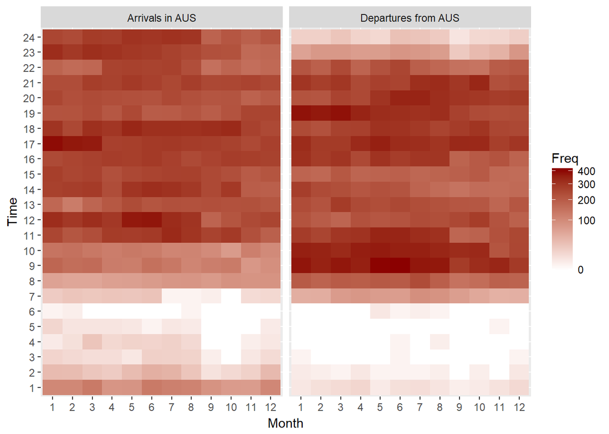

```r
#select columns of interest
focus<-ABIA[,c(2,4,5,7,9,15,16,17,18,25,26,27,28,29)]

focus[,'DIR']=NA
focus[,'DIR'][focus[,'Origin']=='AUS']='Departures from AUS'
focus[,'DIR'][focus[,'Dest']=='AUS']='Arrivals in AUS'
focus[,'DEP']=ceiling(focus[,'DepTime']/100)
focus[,'ARR']=ceiling(focus[,'ArrTime']/100)
focus[,'Time']=ifelse(test = focus[,'DIR']=='DEP', yes = focus[,'DEP'], no = focus[,'ARR'])

pv<-as.data.frame.table(xtabs('~ Month + Time + DIR', data = focus))

# Heat map
heat_map<-ggplot(data = pv, mapping = aes(Month, Time, fill = Freq)) + facet_grid(~ DIR) + geom_tile() + scale_fill_gradient(trans='sqrt', low = 'white', high = 'dark red')
heat_map
```

Large quantities of arrives don’t begin until 11 AM, and they continue past midnight until 2 AM.

Departures from Austin go in two distinct waves - one in the morning at the start of business and another in the evening, centered at 7 PM.

In general, there is more travel in and out of Austin during the summer months.

## Problem 2: Author Attribution

First, one needs to read in the files and create the training and test corpora, then pre-process the corpora (change to lower case, removing stop words, removing punctuation and numbers).

Also, the words in the test and training dataset need to be standardized so that the test and train matrices match.

```r
library(tm)
library(randomForest)
library(knitr)
library(e1071)
library(rpart)
library(caret)
```

```r
library(plyr)

#define readerPlain function
readerPlain = function(fname){
readPlain(elem=list(content=readLines(fname)), id=fname, language='en') }

######################## train ################################

# create file list for importing docs and authors
author_dirs_train = Sys.glob('C:/Users/nsche/OneDrive/MSBA/Predictive Modeling/HW 2/ReutersC50/C50train/*')

file_list_train = NULL
train_labels = NULL

for(author in author_dirs_train) {
  author_name = substring(author, first=75)
  files_to_add = Sys.glob(paste0(author, '/*.txt'))
  file_list_train = append(file_list_train, files_to_add)
  train_labels = append(train_labels, rep(author_name, length(files_to_add)))
}

# apply readerPlain
all_docs_train = lapply(file_list_train, readerPlain)
names(all_docs_train) = file_list_train
names(all_docs_train) = sub('.txt', '', names(all_docs_train))

#create training corpus
corpus_train = Corpus(VectorSource(all_docs_train))

# training corpus pre-processing
corpus_train = tm_map(corpus_train, content_transformer(removeNumbers))
corpus_train = tm_map(corpus_train, content_transformer(removePunctuation))
corpus_train = tm_map(corpus_train, content_transformer(tolower))
corpus_train = tm_map(corpus_train, content_transformer(stripWhitespace))
corpus_train = tm_map(corpus_train, content_transformer(removeWords), stopwords("SMART"))

# create document term matrix
dtm_train = DocumentTermMatrix(corpus_train)
dtm_train = removeSparseTerms(dtm_train, 0.96)

# Now a dense matrix
dtm_train_m = as.matrix(dtm_train)
row.names(dtm_train_m) = file_list_train


######################## test ################################

# create file list for importing docs and authors
author_dirs_test = Sys.glob('C:/Users/nsche/OneDrive/MSBA/Predictive Modeling/HW 2/ReutersC50/C50test/*')
file_list_test = NULL
test_labels = NULL
for(author in author_dirs_test) {
  author_name = substring(author, first=74)
  files_to_add = Sys.glob(paste0(author, '/*.txt'))
  file_list_test = append(file_list_test, files_to_add)
  test_labels = append(test_labels, rep(author_name, length(files_to_add)))
}


# apply readerPlain
all_docs_test = lapply(file_list_test, readerPlain)
names(all_docs_test) = file_list_test
names(all_docs_test) = sub('.txt', '', names(all_docs_test))

# create test corpus
corpus_test = Corpus(VectorSource(all_docs_test))

# test corpus pre-processing
corpus_test = tm_map(corpus_test, content_transformer(removeNumbers))
corpus_test = tm_map(corpus_test, content_transformer(removePunctuation))
corpus_test = tm_map(corpus_test, content_transformer(tolower))
corpus_test = tm_map(corpus_test, content_transformer(stripWhitespace))
corpus_test = tm_map(corpus_test, content_transformer(removeWords), stopwords("SMART"))

# standardize test and training data sets
# create a dictionary with training corpus and take those words from test corpus
dict_train = NULL
dict_train = dimnames(dtm_train)[[2]]

# create testing document term matrix
dtm_test = DocumentTermMatrix(corpus_test, list(dictionary=dict_train))
dtm_test = removeSparseTerms(dtm_test, 0.96)

# Now a dense matrix
dtm_test_m = as.matrix(dtm_test)
row.names(dtm_test_m) = file_list_test
```

Let’s try making a couple models.

### Naive Bayes

```r
# create model
nb_model = naiveBayes(x=dtm_train_m, y=as.factor(train_labels), laplace=1)
# laplace accounts for words not in training dataset
# run the prediction
nb_prediction = predict(nb_model, dtm_test_m)

cm_nb = confusionMatrix(table(nb_prediction,test_labels))
cm_nb_df = as.data.frame(cm_nb$byClass)
cm_nb_df[order(-cm_nb_df$Sensitivity),][1]
```

```
##                          Sensitivity
## Class: RogerFillion             0.40
## Class: AlanCrosby               0.20
## Class: LydiaZajc                0.14
## Class: DavidLawder              0.06
## Class: PeterHumphrey            0.04
## Class: AaronPressman            0.02
## Class: EricAuchard              0.02
## Class: LynneO'Donnell           0.02
## Class: TheresePoletti           0.02
## Class: AlexanderSmith           0.00
## Class: BenjaminKangLim          0.00
## Class: BernardHickey            0.00
## Class: BradDorfman              0.00
## Class: DarrenSchuettler         0.00
## Class: EdnaFernandes            0.00
## Class: FumikoFujisaki           0.00
## Class: GrahamEarnshaw           0.00
## Class: HeatherScoffield         0.00
## Class: JaneMacartney            0.00
## Class: JanLopatka               0.00
## Class: JimGilchrist             0.00
## Class: JoeOrtiz                 0.00
## Class: JohnMastrini             0.00
## Class: JonathanBirt             0.00
## Class: JoWinterbottom           0.00
## Class: KarlPenhaul              0.00
## Class: KeithWeir                0.00
## Class: KevinDrawbaugh           0.00
## Class: KevinMorrison            0.00
## Class: KirstinRidley            0.00
## Class: KouroshKarimkhany        0.00
## Class: LynnleyBrowning          0.00
## Class: MarcelMichelson          0.00
## Class: MarkBendeich             0.00
## Class: MartinWolk               0.00
## Class: MatthewBunce             0.00
## Class: MichaelConnor            0.00
## Class: MureDickie               0.00
## Class: NickLouth                0.00
## Class: PatriciaCommins          0.00
## Class: PierreTran               0.00
## Class: RobinSidel               0.00
## Class: SamuelPerry              0.00
## Class: SarahDavison             0.00
## Class: ScottHillis              0.00
## Class: SimonCowell              0.00
## Class: TanEeLyn                 0.00
## Class: TimFarrand               0.00
## Class: ToddNissen               0.00
## Class: WilliamKazer             0.00
```

```r
Accuracy = mean(cm_nb_df$Sensitivity)

Accuracy
```

```
## [1] 0.0184
```

Naive Baye’s doesn’t seem to be working well. 1.8% accuracy. It can predict with some level of accuracy for Roger Fillion and Alan Crosby, but the accuracy rate quickly drops and hits 0 for the majority of the authors.

### Random Forests

```r
rf_model = randomForest(x=dtm_train_m, y=as.factor(train_labels), mtry=4, ntree=200)
rf_predicted = predict(rf_model, data = dtm_test_m)

#check model accuracy
rf_cm = confusionMatrix(table(rf_predicted,test_labels))
rf_cm$overall
```

```
##       Accuracy          Kappa  AccuracyLower  AccuracyUpper   AccuracyNull
##      0.7096000      0.7036735      0.6913674      0.7273404      0.0200000
## AccuracyPValue  McnemarPValue
##      0.0000000            NaN
```

Okay, that’s better. Random Forests seems to be getting a little over 70% accuracy, which is much better than the Naive Bayes model. I may have messed up somewhere in the Naive Bayes model, but it looks like Random Forests is the superior model for this data set.

## Problem 3: Practice with Association Rule Mining

```r
library(arules)
#read dataset using read.transactions
groceries = read.transactions('C:/Users/nsche/OneDrive/MSBA/Predictive Modeling/HW 2/groceries.txt', format = 'basket', sep = ',', rm.duplicates = FALSE)
```

Using the Apriori algorithm, I created a set of grocery rules with a support theshold of .01 and a confidence threshold of .2. I picked these through trial and error, as increasing support threshold by even a few hundredths drastically reduced the number of rules. Increasing threshold by a couple tenths had the same effect.

```r
grocery_rules <- apriori(groceries, parameter=list(support=.01, confidence=.2, maxlen=8))
```

```
## Apriori
##
## Parameter specification:
##  confidence minval smax arem  aval originalSupport maxtime support minlen
##         0.2    0.1    1 none FALSE            TRUE       5    0.01      1
##  maxlen target   ext
##       8  rules FALSE
##
## Algorithmic control:
##  filter tree heap memopt load sort verbose
##     0.1 TRUE TRUE  FALSE TRUE    2    TRUE
##
## Absolute minimum support count: 98
##
## set item appearances ...[0 item(s)] done [0.00s].
## set transactions ...[169 item(s), 9835 transaction(s)] done [0.00s].
## sorting and recoding items ... [88 item(s)] done [0.00s].
## creating transaction tree ... done [0.00s].
## checking subsets of size 1 2 3 4 done [0.00s].
## writing ... [232 rule(s)] done [0.00s].
## creating S4 object  ... done [0.00s].
```

This created 232 rules.

Let’s look at the items with the highest lift.

```r
inspect(subset(grocery_rules, subset=lift > 3))
```

```
##     lhs                   rhs                     support confidence     lift
## [1] {beef}             => {root vegetables}    0.01738688  0.3313953 3.040367
## [2] {other vegetables,
##      yogurt}           => {whipped/sour cream} 0.01016777  0.2341920 3.267062
## [3] {citrus fruit,
##      root vegetables}  => {other vegetables}   0.01037112  0.5862069 3.029608
## [4] {citrus fruit,
##      other vegetables} => {root vegetables}    0.01037112  0.3591549 3.295045
## [5] {root vegetables,
##      tropical fruit}   => {other vegetables}   0.01230300  0.5845411 3.020999
## [6] {other vegetables,
##      tropical fruit}   => {root vegetables}    0.01230300  0.3427762 3.144780
```

These are the items with the highest lifts, or associations. If one buys beef, he or she is 3.04 times more likley to buy root vegetables. If one buys vegetables and yogurt, he or she is 3.27 times more likely to buy whipped or sour cream.

```r
inspect(subset(grocery_rules, subset=support > .02 & confidence > 0.3 & lift > 2))
```

```
##     lhs                              rhs                support
## [1] {whipped/sour cream}          => {other vegetables} 0.02887646
## [2] {root vegetables}             => {other vegetables} 0.04738180
## [3] {root vegetables,whole milk}  => {other vegetables} 0.02318251
## [4] {other vegetables,whole milk} => {root vegetables}  0.02318251
## [5] {other vegetables,yogurt}     => {whole milk}       0.02226741
## [6] {whole milk,yogurt}           => {other vegetables} 0.02226741
##     confidence lift
## [1] 0.4028369  2.081924
## [2] 0.4347015  2.246605
## [3] 0.4740125  2.449770
## [4] 0.3097826  2.842082
## [5] 0.5128806  2.007235
## [6] 0.3974592  2.054131
```

If you increase the support and confidence, it looks like the clearest associations are between vegetables and other vegetables (surprise), and between different kinds of dairy.